# week-3-tasks

Naida Dzigal

October 06, 2022

# Git branch and pull request

Very good mini course

# Pull request task

- fork my repo pull_request_demo
- clone the forked repository
- create a rmd file inside HA map with your name, calculate the sum of the - first 100 integer and create a ggplot.
- knit into HTML
- commit and push the 2 files to your forked repo
- create a pull request to my repo

# Reproduce the followings

```
## [1] "a" "b" "c" "d" "e"
```

```
##  [1] "a" "c" "e" "g" "i" "k" "m" "o" "q" "s" "u" "w" "y"
```

```
##  [1] "Count 1"  "Count 2"  "Count 3"  "Count 4"  "Count 5"  "Count 6"
##  [7] "Count 7"  "Count 8"  "Count 9"  "Count 10"
```

```
## [1] "a#c#e#g#i#k#m#o#q#s#u#w#y"
```

```
## [1] "a $ c $ e $ g $ i $ k $ m $ o $ q $ s $ u $ w $ y"
```

# Print out the value of

- pi
- round pi to two digits
- square root of pi
- pi power of 5

```
## [1] 3.141593
```

```
## [1] 3.14
```

```
## [1] 1.772454
```

```
## [1] 306.0197
```

# Sequences

```
##  [1] 0.00 0.02 0.04 0.06 0.08 0.10 0.12 0.14 0.16 0.18 0.20 0.22 0.24 0.26 0.28
## [16] 0.30 0.32 0.34 0.36 0.38 0.40 0.42 0.44 0.46 0.48 0.50 0.52 0.54 0.56 0.58
## [31] 0.60 0.62 0.64 0.66 0.68 0.70 0.72 0.74 0.76 0.78 0.80 0.82 0.84 0.86 0.88
## [46] 0.90 0.92 0.94 0.96 0.98 1.00
```

```
##  [1] 1.000000 1.083333 1.166667 1.250000 1.333333 1.416667 1.500000 1.583333
##  [9] 1.666667 1.750000 1.833333 1.916667 2.000000
```

- generate a random number between 0 and 1
- generate 10 random numbers between 0 and 1
- generate 10 random numbers between 0 and 100
- generate 20 integer random numbers between 0 and 10 (it should contain 0 and 10 as well and use runif)
- generate 20 integer random number between 0 and 10 (use sample)

```
## [1] 0.003427465
```

```
##  [1] 0.9507857 0.5359119 0.2133637 0.1823472 0.2682919 0.3970556 0.2327035
##  [8] 0.8285901 0.8874195 0.8293175
```

```
##  [1] 21.41148 43.42738 50.89213 15.12428 83.20354 21.06415 37.18843 28.87636
##  [9] 98.83961 53.85424
```

[output not shown]

```
##  [1]  9  3  0  2  8  9  5  8 10  3  6  9  0  2  5  6  6  5  9  9
```

# Vectors

- check if ‘bear’ is in the animals vector
- check if ‘cat’ and ‘snake’ are in the animal vector
- sum how many of the followings ‘mouse’, ‘wolf’, ‘shark’, ‘bull’ are in the animals vector
- how many of the animals start with the letter b

```
## [1] TRUE
```

```
## [1] TRUE TRUE
```

```
## [1] 2
```

```
## [1] 2
```

# Lists

```r
l <- list('hello', 10, letters)
```

- print out the second element of the vector
- print out the length of the vector inside the list
- check if the number in the list is divisible by 5

```
## [1] "b"
```

```
## [1] 26
```

```
## [1] TRUE
```

Plot sinus curve from 0, to 2pi

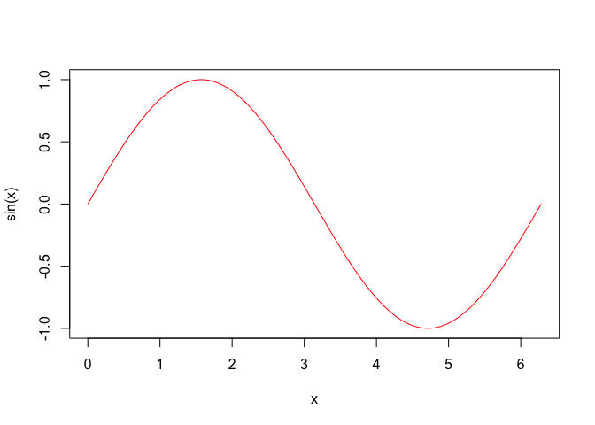

# Data type/structures

List as many data type structure as you can!

For example:

```r
#numeric
i <- 3
str(i)
```

```
##  num 3
```

```r
typeof(i)
```

```
## [1] "double"
```

```r
# string
s <- 'Hello CEU'
str(s)
```

```
##  chr "Hello CEU"
```

```r
typeof(s)
```

```
## [1] "character"
```

```r
#
```

# Prettydoc

Install the prettydoc package

```r
install.packages("prettydoc")
```

Add to the header the following

```r
output:
  prettydoc::html_pretty:
    theme: cayman
    highlight: github
```

Check the prettydoc themes at https://prettydoc.statr.me/